# Reading a State Voter Registration File

One county’s file, the codes that decide which ballot you are handed, and the elections it has already forgotten

Democracy’s Data

Last updated September 13, 2026 at 10:53a EDT

Register to vote and you become a row in a government file. Every campaign that knocks on your door found you in it, every turnout model — a campaign’s guess at who will actually show up — is built on it, and most published claims about who votes come out of it. The file is also, in Georgia, a public record that the state sells to anyone who orders it. So the claim is worth turning into a question and answering from the file itself: **what does the state actually know about you as a voter, and what is that knowledge for?**

## The test

The test is to read one county’s registration file whole, rather than trusting anyone’s summary of one. The file is Houston County, Georgia’s: **127,560 registered voters**, one row each, in the copy the county keeps for its own daily work. Beside it sit the state’s separate records of who voted in the 2020, 2022 and 2024 general elections — its **voter history** files, one row per person per election — matched to the registration rows. Both are public records, and this copy arrived as working material in a 2026 county redistricting matter, which is the ordinary route for a file of this kind.

A registration file is the right instrument for this question because it is the machinery itself, not a report about it. The voter-file chapter gives the source its biography: a list kept under federal law so a poll worker can hand each person the correct ballot. Georgia’s version has one property that matters beyond the state. It records each voter’s **race**, which almost no other state does, so turnout by race can be computed from government records instead of estimated from a survey.

## The data

The county’s extract carries 53 columns per person. The state’s vote-history records arrived separately and were matched to it on the registration number — the **join key**, the one column both files share, so that a row in one can be paired with the row in the other that belongs to the same person. That pairing needed one repair worth knowing about. Registration numbers are stored as text, with leading zeros, and the two systems write them differently. Read the column as a number and `00002779` becomes `2779`, which matches nothing; so both files were read as text, zeros kept, and the history files’ duplicate rows — the same voter listed twice for one election — were reduced to one. Get either step wrong and voters silently vanish from the match.

Almost everything below is a count over all 127,560 rows. There is one deliberate exception: five real registrants, drawn at random and printed exactly as the state publishes them. **Nothing is anonymised**, because Georgia’s list is a public record and a reader who has never seen a row of one does not really know what this brief is about.

| Last Name | First Name | Birth Year | Race | County Precinct | Registration Date | Last Party Voted |
| --- | --- | --- | --- | --- | --- | --- |
| SCHOFILL | JACKSON | 2003 | WHITE | ROZR | 2024-03-01 00:00:00.000 |  |
| CLARK | HOLLY | 1975 | WHITE | VFW | 2002-11-30 00:00:00.000 |  |
| KING | DESI | 1971 | BLACK | WELL | 2007-08-29 00:00:00.000 | NON-PARTISAN |
| BROWN | CHARLES | 1975 | BLACK | HEFS | 1996-11-05 00:00:00.000 |  |
| TOLBERT | TONYA | 1978 | BLACK | WELL | 2025-06-24 00:00:00.000 | DEMOCRAT |

The file also carries, for each of them, a registration number, a street address, a mailing address, and the district codes that decide which ballot they get. Count the party column carefully. Exactly one of the five has a party ballot on record; one reads `NON-PARTISAN`, which is a value and not a party; three are blank. A reader who counts the non-empty cells as partisans is already wrong, and a later section says why.

Take the one row that does carry a party, and read it the way the poll worker’s software does. TONYA TOLBERT, born 1978, is ACTIVE, so may vote today without further paperwork. The precinct code WELL names the polling place, WELLSTON CENTER. Congressional District 002, State Senate District 026, State House District 143, County Commission District LRG and City Council District 5-WARNER ROBINS together pick one ballot style out of the county’s many, which is the whole reason those columns exist. `Race` reads BLACK: one box ticked on a registration form. And `Last Party Voted` reads DEMOCRAT, beside a `Last Vote Date` of 2026-06-16. That is not a party registration. It is the record that this voter asked for that party’s ballot at the primary election held on that date, and it is the only partisan fact the state holds about anyone.

Grouped by what each column is for, the 53 columns look like this:

| What the columns are for | How many columns |
| --- | --- |
| Which ballot you get | 21 |
| Where you live | 8 |
| Where to mail you things | 7 |
| When things happened | 6 |
| Who you are | 5 |
| Demographics | 3 |
| Whether you count | 2 |
| County | 1 |

And two lists are worth holding side by side before any counting starts:

| In the file | Not in the file |
| --- | --- |
| That you voted, and on which date | Who you voted for, ever, in anything |
| Which party’s primary ballot you last requested | Any statement of party affiliation |
| Your race, as one box on a form | Anything about how you describe yourself now |
| Your address, precinct, and ten district codes | Whether any of it is still true |

The secret ballot does real work here. The state can know *that* you voted and never *whom* you chose. Everything the file supports, from targeting to turnout models to this brief itself, lives inside that boundary.

> **Before you read on, put a number to it.** Of the people who actually cast a ballot in this county in November 2020, what share are missing from the 2026 file altogether — dead, moved away, or struck off? Commit to a percentage before you read on. Then commit to a second answer: would you expect the people who vanished to have voted at about the same rate as the people who stayed? A table below settles the first question. Nothing in this file will ever settle the second.

## What it says about democracy

Here is the record itself: every column the file keeps about one person, drawn in the order the file stores them.

One voter’s record: all 53 columns in the order the file stores them, colored by what each one is for, with the legend counting the columns in each group. Columns 18 to 38 are a single unbroken run of 21 district codes, 39.6% of the record.

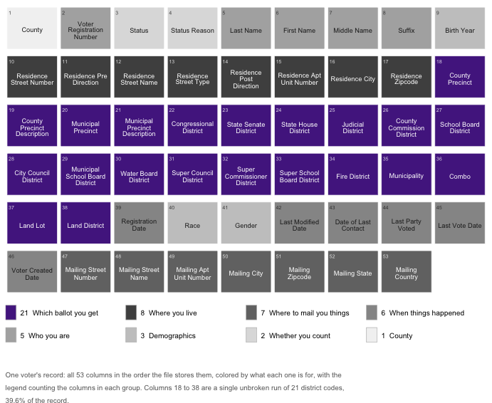

**Figure 1. One voter’s record, every column, in the order the file stores them.** A field strip fits this question because the finding is about the record’s own anatomy: each cell is a column, colored by the job it does. The purple block is the ballot-routing run — 21 of the 53 columns, 39.6% of the whole record, unbroken from column 18 to column 38.

That is not a description of an electorate. **It is a routing table.** Congressional district, state senate, state house, judicial, school board, water board, fire district: the columns exist so a poll worker can hand one specific person one specific piece of paper. Nobody designed this file to answer a research question. Everything researchers take from it, from who registered when to who turned out to who lives where, is a by-product of that clerical job.

The column that looks most like politics proves the point. It is labeled `Last Party Voted`, and journalists quote it as party registration. **Georgia has no party registration** — no box on the form where a voter declares a party, as there is in most states.[^1] The column records only which party’s *primary ballot* you last requested, and most rows have nothing in it:

| Quantity | Value |
| --- | --- |
| Registered voters | 127,560 |
| Blank — no primary ballot on record | 40,663 |
| Marked NON-PARTISAN | 48,603 |
| Carrying no usable party signal | 89,266 (70.0%) |

**70.0% of this file carries no party signal at all.** Anyone who tells you how many registered Democrats there are in Georgia is using another state’s data or making it up. Among the minority who did take a partisan primary ballot, the record is strong precisely because it is administrative — these are ballots people actually asked for, not answers to an interviewer:

| Race | Dem | Rep | D per R | R per D |
| --- | --- | --- | --- | --- |
| ASIAN/PACIFIC ISLANDER | 224 | 307 | 0.7 | 1.4 |
| BLACK | 13814 | 442 | 31.3 | 0.0 |
| HISPANIC/LATINO | 355 | 285 | 1.2 | 0.8 |
| OTHER | 1244 | 877 | 1.4 | 0.7 |
| WHITE | 3554 | 16715 | 0.2 | 4.7 |

Black voters in this county broke Democratic over Republican by 31 to one; white voters broke Republican by 4.7 to one. It describes only the most engaged 3 in ten, and it is still a kind of evidence no survey can match.

Who counts as registered is itself a decision the file records:

| Status | Reason recorded | Voters |
| --- | --- | --- |
| ACTIVE |  | 118,174 |
| INACTIVE | NO CONTACT | 3,029 |
| INACTIVE | NCOA | 2,654 |
| INACTIVE | CROSS STATE | 2,322 |
| INACTIVE | RETURNED MAIL | 1,381 |

**9,386 people on this list are marked INACTIVE, and none of them did anything.** Every reason in that column is an event in a mail system: a returned letter, a change-of-address match (`NCOA` is the Postal Service’s list of forwarding requests), a report from another state. The flag is the first step of what the law calls **list maintenance** and its critics call a purge: an inactive registrant who does not answer a mailed notice, and then sits out the next two federal general elections, may be removed from the list. The National Voter Registration Act forbids removing people *for* not voting.[^2] Ohio treats a missed election as grounds to send a confirmation letter, and *Husted v. A. Philip Randolph Institute* (2018) upheld that practice five to four.[^3] Put as a data question: is a returned envelope evidence about a person, or about the postal system?

| “registered voters” could mean | Count |
| --- | --- |
| Everyone on the list | 127,560 |
| Active registrants only | 118,174 |

This one flag decides whether “registered voters” here means 127,560 or 118,174 — a gap of 7.4%. Every turnout rate is a fraction, and this is its **denominator**, the bottom number you divide by. Which of the two counts a publication used is almost never stated.

Now the number the file is most often used to produce. Take how many people of each race are recorded as voting in November 2024, and divide by how many are in the file:

| Race | In the 2026 file | Recorded voting in 2024 | Turnout rate (%) |
| --- | --- | --- | --- |
| WHITE | 65,116 | 45,030 | 69.2 |
| OTHER | 7,748 | 4,369 | 56.4 |
| ASIAN/PACIFIC ISLANDER | 3,547 | 1,959 | 55.2 |
| BLACK | 42,603 | 23,467 | 55.1 |
| HISPANIC/LATINO | 4,518 | 2,154 | 47.7 |
| AMERICAN INDIAN | 1,849 | 706 | 38.2 |
| UNKNOWN | 2,175 | 645 | 29.7 |

White 69.2%, Black 55.1%, a spread of 39.5 points top to bottom. That is a publishable finding, and it has a defect the file itself can measure. Every rate in the table has a **numerator**, the top number of the fraction, taken from 2024 — and a denominator from 2026. Match the state’s own record of who voted against the current file and here is what those years apart cost:

| Election | Recorded as voting | Still in the 2026 file | No longer in the file | % vanished |
| --- | --- | --- | --- | --- |
| 2020 general | 74,394 | 60,591 | 13,803 | 18.6 |
| 2022 general | 59,280 | 53,603 | 5,677 | 9.6 |
| 2024 general | 82,132 | 78,334 | 3,798 | 4.6 |

[figure not shown]

**Figure 2. The share of each election’s actual voters who are no longer in the 2026 file.** Three bars, one per election, because the finding is a single rate read against time. The further back the election, the more of its voters have left the file that would be used to study it; hover a bar for the counts behind it.

**13,803 people voted in the 2020 general election and are not in the 2026 file at all** — 18.6% of everyone who voted here that November, roughly one voter in 5, in six years. They died, moved away, or were removed. Even 2024’s electorate has lost 4.6% in under two years. A voter file is a photograph of a system that is still running, not an archive; the list has no past tense, and nothing in it warns you.

The loss is not a random sample, either. Leaving a county is what movers do, and movers are younger, poorer and likelier to rent than the people who stay.[^4] So a turnout rate computed backward from a current file is not just noisy. It is wrong in a direction nobody can measure from inside the file, because the people who would settle it are exactly the ones who are gone.

## What this brief cannot tell you

**It cannot say how anyone voted.** The history file records that you voted, never your choices; the secret ballot makes that permanent, and every model that claims to know is guessing across the gap.

**It cannot produce a correct turnout rate for any past election.** The denominator that rate needs is the file as it stood on that election day, and most states overwrite it. Nor can it say whether the 18.6% who vanished voted like the people who stayed — the question that decides whether any backward-looking rate is close.

**It cannot say whether list maintenance is neutral.** The reasons recorded are postal events, postal reliability is not evenly distributed, and no column here measures who the process reaches hardest.

**And it is one county in one state.** The shape travels; the columns do not. Most states record no race at all, about half record a party registration Georgia lacks, and the commercial files campaigns actually use carry hundreds of modeled columns nobody outside the vendor can inspect.[^5]

## What you should have learned

- A voter file is a routing table: 21 of this file’s 53 columns exist to hand one person the right ballot, 39.6% of the whole record.
- The column that looks like party is not party: 70.0% of the file carries no party signal, because Georgia registers nobody by party and records only the last primary ballot requested.
- “Registered voters” is a choice: 127,560 with inactives, 118,174 without, a 7.4% gap in every rate’s denominator, and the inactive flag records mail events rather than anything a voter did.
- The file has no memory: 13,803 of 2020’s actual voters — 18.6% — are already gone from the 2026 file, and the loss is not random.
- Georgia records race at registration, which is why turnout by race — a 39.5-point spread in 2024 — can be computed here from records rather than surveys.

## Extensions

None of these is answered above, and every one can be answered from the tables the Sources section hands over.

- `status.csv` breaks registrations into `status` and `reason`. Work out what share of the file is not active. Who is in a voter file but cannot vote from it without further paperwork?
- `lost.csv` counts, in `voters_no_longer_in_file`, the voters of each election who have left. Work out what that does to anyone computing a 2020 turnout rate from the current file.
- `columns.csv` says how each column is `stored` and how many `distinct` values it takes. Find a column stored as a number that is not a quantity. What breaks if software averages it?
- `turnout.csv` gives each race group `in_file_2026` and its recorded voters in `2020 general`, `2022 general` and `2024 general`. Compute the three rates per group. Which gaps persist across all three elections?
- `race_party.csv` counts each group’s `DEMOCRAT`, `REPUBLICAN`, `NON-PARTISAN` and blank rows. What share of each group left any partisan trace at all?

Two stretch ideas point past the spreadsheet. Georgia sells its statewide list to anyone; the order page is in the sources — price one, and compare what your own state would charge and require. And North Carolina posts its statewide file free, so download it and check which of this brief’s columns exist there, which do not, and what question each state has made unanswerable.

## Sources

**Data**

- The Houston County, Georgia voter registration file. A public record in Georgia; this copy arrived as working material in a 2026 county redistricting matter. Almost everything printed here is a count over the whole file. **Five whole records are also printed, names included and nothing replaced**, because the list is a public record and this book does not redact public records. Georgia sells the list to anyone who orders it, and that is where a reader would start. https://sos.ga.gov/page/order-voter-registration-lists-and-files
- The state’s records of who voted in the 2020, 2022 and 2024 general elections. **These did not come with the registration file.** They are a separate public record, requested separately and matched on the registration number — the repair described above, which is why numbering the two files differently would inflate the decay this brief measures. Georgia publishes voter history files of its own. https://mvp.sos.ga.gov/s/voter-history-files

**Academic literature**

- Ansolabehere, S. and Hersh, E. (2012). “Validation: What Big Data Reveal About Survey Misreporting and the Real Electorate.” *Political Analysis* 20(4): 437–459. https://doi.org/10.1093/pan/mps023
- Hersh, E. D. (2015). *Hacking the Electorate: How Campaigns Perceive Voters.* Cambridge University Press. https://doi.org/10.1017/CBO9781316212783
- National Voter Registration Act of 1993, 52 U.S.C. § 20501 et seq.; the list-maintenance rules are § 20507. https://www.law.cornell.edu/uscode/text/52/20507
- *Husted v. A. Philip Randolph Institute*, 584 U.S. 756 (2018). https://www.law.cornell.edu/supremecourt/text/16-980
- *Shelby County v. Holder*, 570 U.S. 529 (2013). https://www.law.cornell.edu/supremecourt/text/12-96 Section 5 preclearance is why Georgia collects race at registration; the coverage formula fell, the collection remained.

**The data itself**

Every figure above is drawn from these tables. They are plain CSV, they open in a spreadsheet, and they are yours to take further.

`columns.csv`, `deadlines.csv`, `headscan.csv`, `lost.csv`, `peek.csv`, `race_party.csv`, `registration.csv`, `schema.csv`, `status.csv`, `turnout.csv`

Why this data cannot be fetched again

[output not shown]

[^1]: The National Conference of State Legislatures lists which states register by party and which, like Georgia, hold primaries open to any registered voter: https://www.ncsl.org/elections-and-campaigns/state-primary-election-types.
[^2]: 52 U.S.C. §20507(b)(2) and (d), https://www.law.cornell.edu/uscode/text/52/20507.
[^3]: *Husted v. A. Philip Randolph Institute*, 584 U.S. 756 (2018), https://www.law.cornell.edu/supremecourt/text/16-980.
[^4]: The Census Bureau’s Current Population Survey tables on geographic mobility, by age, income and whether the household owns or rents: https://www.census.gov/topics/population/migration/data/tables.html.
[^5]: Eitan D. Hersh, *Hacking the Electorate: How Campaigns Perceive Voters* (Cambridge University Press, 2015), https://doi.org/10.1017/CBO9781316212783.